# Chapter 11

# 11 Bounds constraints

## 11.1 Single bound: use of a logarithmic transformation

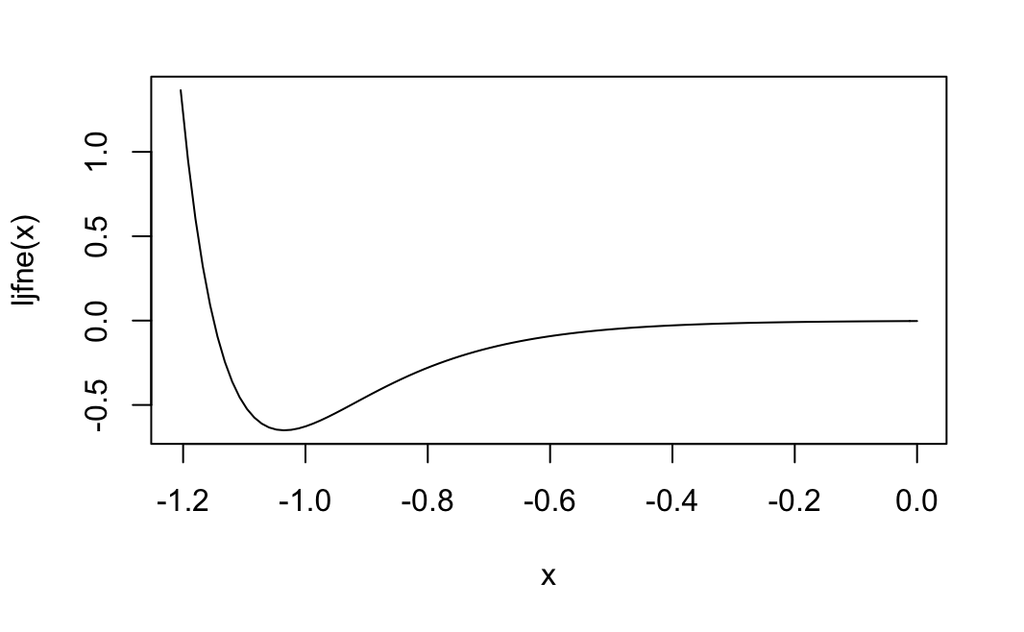

```r
## ----label=C11ljexp, cache=TRUE, echo=TRUE-------------------------------
# The L-J potential function
ljfne <- function(logr, ep = .6501696, sig = .3165555) {
  r <- exp(logr)
  fn <- 4 * ep * ((sig / r)^12 - (sig / r)^6)
}
# Use next line to see a graph of the transformed function
curve(ljfne, from = log(0.3), to = log(1))
```

```r
min <- optimize(ljfne, interval = c(-10, 10))
print(min)
```

```
$minimum
[1] -1.0347

$objective
[1] -0.65017
```

```r
cat("In the original scale, minimum is at ", exp(min$minimum), "\n")
```

```
In the original scale, minimum is at  0.35532
```

```r
# The L-J potential function
ljfn <- function(r, ep = 0.6501696, sig = 0.3165555) {
  fn <- 4 * ep * ((sig / r)^12 - (sig / r)^6)
}
min <- optimize(ljfn, interval = c(0.001, 5))
min
```

```
$minimum
[1] 0.35531

$objective
[1] -0.65017
```

## 11.2 Interval bounds: Use of a hyperbolic transformation

### 11.2.2 A fly in the ointment

```r
## ----label=C11flb1, echo=TRUE, cache=TRUE--------------------------------
require(optimx)
flb <- function(x) {
  p <- length(x)
  sum(c(1, rep(4, p - 1)) * (x - c(1, x[-p])^2)^2)
}
start <- rep(2, 4)
lo <- rep(2, 4)
up <- rep(4, 4)
ans4a <- try(optimx(start, fn = flb, method = c("nmkb"), lower = lo, upper = up))
ans4a
```

```
[1] "Error in as.data.frame.default(x[[i]], optional = TRUE) : \n  cannot coerce class ‘\"function\"’ to a data.frame\n"
attr(,"class")
[1] "try-error"
attr(,"condition")
<simpleError in as.data.frame.default(x[[i]], optional = TRUE): cannot coerce class ‘"function"’ to a data.frame>
```

### 11.3 Setting the objective large when bounds are violated

```r
flbp <- function(x, flo, fup) {
  p <- length(x)
  val <- sum(c(1, rep(4, p - 1)) * (x - c(1, x[-p])^2)^2)
  if (any(x < flo) || any(x > fup)) val <- 1e300
  val
}
start <- rep(2, 4)
lo <- rep(2, 4)
up <- rep(4, 4)
ans4p <- optimx(start, fn = flbp, method = c("hjkb", "Nelder-Mead", "nmkb"), flo = lo, fup = up)
print(summary(ans4p))
```

|  | p1 | p2 | p3 | p4 | value | fevals | gevals | niter | convcode | kkt1 | kkt2 | xtime |
| --- | --- | --- | --- | --- | --- | --- | --- | --- | --- | --- | --- | --- |
| hjkb | NA | NA | NA | NA | 8.9885e+307 | NA | NA | NA | 9999 | NA | NA | 0.002 |
| Nelder-Mead | 2.0067 | 2 | 2 | 3.946 | 3.3457e+01 | 449 | NA | NA | 0 | FALSE | FALSE | 0.007 |
| nmkb | NA | NA | NA | NA | 8.9885e+307 | NA | NA | NA | 9999 | NA | NA | 0.000 |

## 11.4 An active set approach

```r
require(optimx)
flb <- function(x) { # include this again so script is self-standing
  p <- length(x)
  sum(c(1, rep(4, p - 1)) * (x - c(1, x[-p])^2)^2)
}
start <- rep(2, 4)
lo <- rep(2, 4)
up <- rep(4, 4)
ans4 <- optimx(start, fn = flb, method = c("Rvmmin", "L-BFGS-B", "bobyqa"), lower = lo, upper = up, control = list(usenumDeriv = TRUE))
```

```
trace= 0
```

```r
# print(summary(ans4))
ans4
```

|  | p1 | p2 | p3 | p4 | value | fevals | gevals | niter | convcode | kkt1 | kkt2 | xtime |
| --- | --- | --- | --- | --- | --- | --- | --- | --- | --- | --- | --- | --- |
| Rvmmin | 2 | 2 | 2.0000 | 2 | 49.000 | 1 | 1 | NA | 0 | FALSE | NA | 0.005 |
| L-BFGS-B | 2 | 2 | 2.1091 | 4 | 32.106 | 7 | 7 | NA | 0 | FALSE | TRUE | 0.002 |
| bobyqa | 2 | 2 | 2.1091 | 4 | 32.106 | 44 | NA | NA | 0 | FALSE | TRUE | 0.000 |

## 11.5 Checking bounds

```r
## ----label=C11boundchk1, echo=TRUE, cache=TRUE---------------------------
require(optextras)
## extract first solution from ans4
ans41 <- ans4[2, ]
c41 <- coef(ans41) ## get coefficients
bdc <- bmchk(c41, lower = lo, upper = up, trace = 1)
```

```
admissible =  TRUE
maskadded =  FALSE
parchanged =  FALSE
At least one parameter is on a bound
```

```r
bdc #print(bdc$bchar)
```

```
$bvec
         p1 p2     p3 p4
L-BFGS-B  2  2 2.1091  4

$bdmsk
[1] -3 -3  1 -1

$bchar
[1] "L" "L" "F" "U"

$lower
[1] 2 2 2 2

$upper
[1] 4 4 4 4

$nolower
[1] FALSE

$noupper
[1] FALSE

$bounds
[1] TRUE

$admissible
[1] TRUE

$maskadded
[1] FALSE

$parchanged
[1] FALSE

$feasible
[1] TRUE

$onbound
[1] TRUE
```

## 11.7 Post-solution information for bounded problems

경계가 제한된 최적화 문제에 대한 솔루션은 통계적 해석을 위한 보고 문제를 제기합니다. 매개변수가 한계에 도달하면 표준 오류에 대한 해석이 어색합니다. 우리는 일반적으로 보고된 양의 불확실성의 척도로 표준 오차를 고려합니다. 그러나 추정값에 대해 대칭적인 등의 조치를 취하는 것이 관례이다. 경계의 존재는 기껏해야 반구간에서 해석을 유효한 것으로 렌더링합니다. 두 가지 계산 선택이 있습니다.

- 헤세 행렬, 기울기, 표준 오차 및 결과 통계를 다음과 같이 보고합니다. 경계가 없었다. 이것은 optimHess() 함수의 선택입니다.
- 헤세 행렬, 기울기 및 결과 통계의 적절한 요소를 0으로 만듭니다. 이것은 nlmrt 및 내가 개발 팀의 일부로 참여한 다른 코드를 사용한 선택입니다.

내가 선택한 것은 최적화 방법이 실제로 그라디언트 등을 실제로 0으로 만들기 때문에 이전에 경계 작업에 대해 논의한 것입니다. 물론 제약이 없는 Jacobian 또는 Hessian은 별도로 계산할 수 있습니다. 나는 두 가지 선택 모두 제 자리가 있다고 생각합니다. 불행히도 경계가 있는 상태에서 불확실성을 보고하는 문제에 대해 잘 구성된 논의가 많지 않은 것 같습니다. 여기에 작은 예가 있습니다. 특정 매개변수와 함께 표시되는 기울기 및 야코비안 특이값은 해당 매개변수와 직접 관련되지 않습니다.

```r
require(nlmrt)
source("resources/C12lhobbs.r", echo = FALSE) # to provide the function and gradient
y <- c(
  5.308, 7.24, 9.638, 12.866, 17.069, 23.192, 31.443, 38.558,
  50.156, 62.948, 75.995, 91.972
)
t <- 1:12
wdata <- data.frame(y = y, t = t)
anlxb <- nlxb(y ~ 100 * asym / (1 + 10 * strt * exp(-0.1 * rate * t)),
  start = c(asym = 2, strt = 2, rate = 2), lower = c(2, 2, 2),
  upper = c(4, 4, 4), data = wdata, trace = FALSE
)
print(anlxb)
```

```
nlmrt class object: x
residual sumsquares =  27.72  on  12 observations
    after  9    Jacobian and  10 function evaluations
  name            coeff          SE       tstat      pval      gradient    JSingval
asym                   2L           NA         NA         NA           0       102.7
strt                   4U           NA         NA         NA           0           0
rate             2.90391            NA         NA         NA  -7.752e-07           0
```

```r
# Get unconstrained Jacobian and its singular values
# First create the function (you can display it if you wish)
myformula <- y ~ 100 * asym / (1 + 10 * strt * exp(-0.1 * rate * t))
# The parameter vector values are unimportant; the names are needed
mj <- model2jacfun(myformula, pvec = coef(anlxb))
# Evaluate at the solution parameters
mjval <- mj(prm = coef(anlxb), y = y, t = t)
# and display the singular values
print(svd(mjval)$d)
```

```
[1] 131.4248   7.6714   2.6137
```

```r
# Create the sumsquares function
mss <- model2ssfun(myformula, pvec = coef(anlxb))
# Evaluate gradient at the solution
require(numDeriv)
mgrval <- grad(mss, x = coef(anlxb), y = y, t = t)
print(mgrval)
```

```
[1]  6.6324e+01 -6.0970e+01  8.0053e-06
```

```r
# Evaluate the hessian at the solution (x rather than prm!)
mhesssval <- hessian(mss, x = coef(anlxb), y = y, t = t)
print(eigen(mhesssval)$values)
```

```
[1] 34617.706   151.004    28.294
```

그래디언트가 0에 가깝지 않다는 점에 유의하십시오. 우리는 경계 제약 조건에 있습니다. 위의 코드는 같은 양에 start, pvec, prm, 같은 다른 기능에서 다른 이름이 지정되는 일반적인 R 성가심이 있지만 솔루션과 관련하여 검토할 수 있는 양을 얻는 것이 상당히 쉽다는 것을 보여줍니다. 그리고 엑스. 그리고 이 부분을 쓰면서 내가 이 점에 있어서 유죄임을 상기시켜 주었다. 통계 외에 최적화는 일반적으로 다른 종류의 불확실성, 즉 제약 조건의 엄격함을 살펴봅니다. 분명히 우리는 log(0) 또는 이와 유사한 불가능으로 이어지는 경계를 완화할 수 없습니다. 그러나 일부 경제 모델에서 상품의 가격 하한선과 같은 많은 범위는 정책 문제입니다. 이 후자의 상황에서 우리는 제약(즉, 경계)의 단위 변화당 목적 함수의 변화율을 고려할 수 있습니다. 이것은 그림자 가격의 개념입니다(http://en.wikipedia.org/wiki/Shadow_price). 이 개념은 선형 계획법과 가장 일반적으로 연관되며, 비선형 함수 최소화의 유계 솔루션에 대해 그러한 정보를 제공하는 R 패키지를 알지 못합니다.

```r
## ----label=C11transfinite, echo=TRUE, cache=TRUE-------------------------
##  --------------------------------------------------------------------
##  t r a n s f i n i t e . R
##  --------------------------------------------------------------------

transfinite <- function(lower, upper, n = length(lower)) {
  stopifnot(is.numeric(lower), is.numeric(upper))
  if (any(is.na(lower)) || any(is.na(upper))) {
    stop("Any 'NA's not allowed in 'lower' or 'upper' bounds.")
  }
  if (length(lower) != length(upper)) {
    stop("Length of 'lower' and 'upper' bounds must be equal.")
  }
  if (any(lower == upper)) {
    stop("No component of 'lower' can be equal to the one in 'upper'.")
  }
  if (length(lower) == 1 && n > 1) {
    lower <- rep(lower, n)
    upper <- rep(upper, n)
  } else if (length(lower) != n) {
    stop("If 'length(lower)' not equal 'n', then it must be one.")
  }

  low.finite <- is.finite(lower)
  upp.finite <- is.finite(upper)
  c1 <- low.finite & upp.finite # both lower and upper bounds are finite
  c2 <- !(low.finite | upp.finite) # both lower and upper bounds infinite
  c3 <- !(c1 | c2) & low.finite # finite lower bound, infinite upper bound
  c4 <- !(c1 | c2) & upp.finite # finite upper bound, infinite lower bound

  q <- function(x) {
    if (any(x < lower) || any(x > upper)) {
      return(rep(NA, n))
    }

    qx <- x
    qx[c1] <- atanh(2 * (x[c1] - lower[c1]) / (upper[c1] - lower[c1]) - 1)
    qx[c3] <- log(x[c3] - lower[c3])
    qx[c4] <- log(upper[c4] - x[c4])
    return(qx)
  }

  qinv <- function(x) {
    qix <- x
    qix[c1] <- lower[c1] + (upper[c1] - lower[c1]) / 2 * (1 + tanh(x[c1]))
    qix[c3] <- lower[c3] + exp(x[c3])
    qix[c4] <- upper[c4] - exp(x[c4])
    return(qix)
  }
  return(list(q = q, qinv = qinv))
}
```